# PROJET 3PDQ

### Installation des packages

```python
# Packages
import pandas as pd
import numpy as np
import seaborn as sns
import matplotlib.pyplot as plt
import scipy.stats as st
from sklearn.ensemble import IsolationForest
import warnings
# warnings.filterwarnings('ignore')
```

```python
dataset = pd.read_csv("3PDQ - Feuil1.csv")
dataset
```

|  | N°de_Patient | Centre | Initiales | Sexe | Age | Date_Naissance | Date_visite1 | Date_visite2 | EVA_mean | EVA_max | ... | HADa.5 | HADd.5 | HADa.6 | HADd.6 | HADa.7 | HADd.7 | Anxiété_Total | Depression_Total | Total_Score | Conformité_au_protocol |
| --- | --- | --- | --- | --- | --- | --- | --- | --- | --- | --- | --- | --- | --- | --- | --- | --- | --- | --- | --- | --- | --- |
| 0 | 1 | 1 | BM | M | 71.0 | juil.-46 | 2019/05/22 | 2019/05/22 | 50.0 | 60.0 | ... | 0.0 | 0.0 | 0.0 | 0.0 | 0.0 | 0.0 | 2.0 | 3.0 | 5.0 | 1 |
| 1 | 2 | 1 | BM | M | 49.0 | sept.-69 | 2019/06/28 | 2019/06/28 | 35.0 | 80.0 | ... | 0.0 | 1.0 | 1.0 | 1.0 | 0.0 | 0.0 | 3.0 | 4.0 | 7.0 | 1 |
| 2 | 3 | 1 | NC | F | 61.0 | août-57 | 2019/07/05 | 2019/07/05 | 50.0 | 75.0 | ... | 2.0 | 2.0 | 3.0 | 1.0 | 2.0 | 1.0 | 16.0 | 10.0 | 26.0 | 1 |
| 3 | 4 | 1 | GE | F | 65.0 | juil.-53 | 2019/07/10 | 2019/07/10 | 54.0 | 80.0 | ... | 1.0 | 0.0 | 2.0 | 1.0 | 2.0 | 0.0 | 11.0 | 6.0 | 17.0 | 1 |
| 4 | 5 | 1 | ML | F | 59.0 | oct.-58 | 2019/07/17 | 2019/07/17 | 51.0 | 69.0 | ... | 1.0 | 2.0 | 3.0 | 2.0 | 1.0 | 2.0 | 11.0 | 16.0 | 27.0 | 1 |
| ... | ... | ... | ... | ... | ... | ... | ... | ... | ... | ... | ... | ... | ... | ... | ... | ... | ... | ... | ... | ... | ... |
| 220 | 221 | 14 | GM | F | 65.0 | mai-55 | 2022/03/10 | 2022/03/11 | 70.0 | 80.0 | ... | 2.0 | 2.0 | 2.0 | 1.0 | 2.0 | 1.0 | 15.0 | 10.0 | 25.0 | 1 |
| 221 | 222 | 15 | MM | M | 76.0 | févr.-45 | 2022/06/02 | 2022/06/02 | 80.0 | 100.0 | ... | 0.0 | 0.0 | 2.0 | 0.0 | 0.0 | 1.0 | 4.0 | 3.0 | 7.0 | 1 |
| 222 | 223 | 15 | PA | F | 64.0 | nov.-56 | 2022/06/21 | 2022/06/21 | 45.0 | 70.0 | ... | 0.0 | 2.0 | 3.0 | 0.0 | 0.0 | 0.0 | 4.0 | 3.0 | 7.0 | 1 |
| 223 | 224 | 15 | TL | M | 60.0 | févr.-61 | 2022/06/30 | 2022/06/30 | 40.0 | 70.0 | ... | 2.0 | 0.0 | 0.0 | 2.0 | 2.0 | 0.0 | 10.0 | 7.0 | 17.0 | 1 |
| 224 | 225 | 15 | MC | F | 45.0 | nov.-76 | 2022/07/19 | 2022/07/19 | 88.0 | 90.0 | ... | 2.0 | 2.0 | 1.0 | 1.0 | 2.0 | 2.0 | 15.0 | 13.0 | 28.0 | 1 |

225 rows × 292 columns

```python
dataset.shape
```

```
(225, 292)
```

```python
print(dataset.columns.tolist())
```

```
['N°de_Patient', 'Centre ', 'Initiales', 'Sexe', 'Age', 'Date_Naissance', 'Date_visite1', 'Date_visite2', 'EVA_mean', 'EVA_max', 'Inclusion1', 'Inclusion2', 'Inclusion3', 'Inclusion4', 'Inclusion5', 'Inclusion6', 'Inclusion7', 'Non_Inclusion1', 'Non_Inclusion2', 'Non_Inclusion3', 'Non_Inclusion4', '…
```

```python
df= dataset[['item1', 'item2', 'item3', 'item4', 'item5', 'item6', 'item7', 'item8', 'item9', 'item10', 'item11', 'item12', 'item13', 'item14', 'item15', 'item16', 'item17', 'item18',
'item19', 'item20', 'item21', 'item22', 'item23', 'item24', 'item25', 'item26', 'item27', 'item28','Douleur_Centrale']]
df
```

|  | item1 | item2 | item3 | item4 | item5 | item6 | item7 | item8 | item9 | item10 | ... | item20 | item21 | item22 | item23 | item24 | item25 | item26 | item27 | item28 | Douleur_Centrale |
| --- | --- | --- | --- | --- | --- | --- | --- | --- | --- | --- | --- | --- | --- | --- | --- | --- | --- | --- | --- | --- | --- |
| 0 | 0.0 | 1.0 | 1 | 0.0 | 1 | 0 | 1.0 | 0 | 0.0 | 0 | ... | 0 | 0 | 1 | 1 | 0 | 1 | 0 | 0 | 0 | 1.0 |
| 1 | 1.0 | 0.0 | 0 | 1.0 | 0 | 0 | 1.0 | 1 | 0.0 | 0 | ... | 0 | 0 | 1 | 1 | 1 | 1 | 1 | 0 | 0 | 1.0 |
| 2 | 0.0 | 0.0 | 0 | 0.0 | 1 | 0 | 1.0 | 0 | 0.0 | 0 | ... | 0 | 0 | 0 | 0 | 0 | 0 | 1 | 0 | 0 | 0.0 |
| 3 | 0.0 | 1.0 | 1 | 0.0 | 0 | 0 | 1.0 | 0 | 1.0 | 0 | ... | 0 | 0 | 0 | 1 | 1 | 0 | 0 | 0 | 0 | 0.0 |
| 4 | 1.0 | 0.0 | 1 | 1.0 | 1 | 0 | 0.0 | 1 | 0.0 | 0 | ... | 0 | 1 | 0 | 1 | 1 | 0 | 0 | 0 | 0 | 1.0 |
| ... | ... | ... | ... | ... | ... | ... | ... | ... | ... | ... | ... | ... | ... | ... | ... | ... | ... | ... | ... | ... | ... |
| 220 | 0.0 | 1.0 | 1 | 0.0 | 0 | 0 | 1.0 | 1 | 0.0 | 0 | ... | 0 | 0 | 1 | 1 | 1 | 1 | 1 | 0 | 0 | 0.0 |
| 221 | 1.0 | 1.0 | 1 | 0.0 | 1 | 0 | 1.0 | 0 | 0.0 | 0 | ... | 0 | 0 | 0 | 1 | 1 | 1 | 0 | 1 | 0 | 1.0 |
| 222 | 0.0 | 0.0 | 0 | 0.0 | 0 | 0 | 0.0 | 0 | 1.0 | 1 | ... | 0 | 0 | 0 | 1 | 1 | 0 | 0 | 0 | 0 | 1.0 |
| 223 | 0.0 | 0.0 | 0 | 0.0 | 1 | 0 | 0.0 | 1 | 0.0 | 1 | ... | 0 | 0 | 1 | 1 | 1 | 1 | 1 | 1 | 0 | 1.0 |
| 224 | 1.0 | 0.0 | 0 | 0.0 | 1 | 1 | 1.0 | 0 | 0.0 | 0 | ... | 1 | 1 | 1 | 1 | 1 | 1 | 1 | 1 | 1 | 1.0 |

225 rows × 29 columns

```python
df.shape
```

```
(225, 29)
```

### Objectif :

```
1- Prédire la variable Y qui est la douleur centrale
2- Sortir les items qui expliquent le mieux mon Y
```

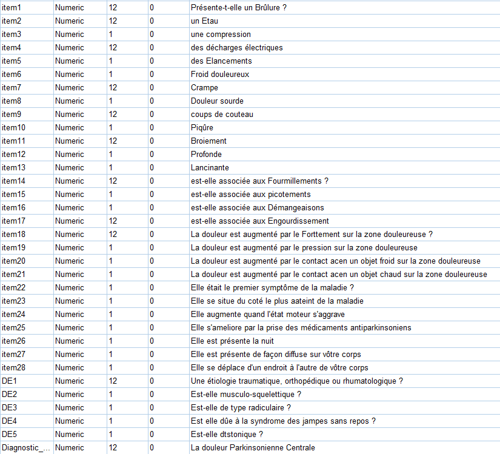

```python
from IPython.display import Image

# Afficher l'image
Image(filename="C:/Users/aliah/Downloads/Capture d’écran 2023-04-21 140544.png")
```

### Vérifier le type de chaque variable

```python
df.select_dtypes(object).columns
```

```
Index(['item3', 'item5', 'item6', 'item8', 'item10', 'item12', 'item13',
       'item15', 'item16', 'item19', 'item20', 'item21', 'item22', 'item23',
       'item24', 'item25', 'item26', 'item27', 'item28'],
      dtype='object')
```

### Conversion de toutes les variables en float

```python
# Convertir les colonnes object en float
for col in df.columns:
    if df[col].dtype == 'object':
        df[col] = pd.to_numeric(df[col], errors='coerce')

# Afficher les types de données des colonnes
print(df.dtypes)
```

```
item1               float64
item2               float64
item3               float64
item4               float64
item5               float64
item6               float64
item7               float64
item8               float64
item9               float64
item10              float64
item11              float64
item12              float64
item13              float64
item14              float64
item15              float64
item16              float64
item17              float64
item18              float64
item19              float64
item20              float64
item21              float64
item22              float64
item23              float64
item24              float64
item25              float64
item26              float64
item27              float64
item28              float64
Douleur_Centrale    float64
dtype: object
```

# Gestion des données manquantes

```python
#Compter le nombre de valeurs manquantes par variable
missing_values_count = df.isnull().sum()

# Afficher le nombre de valeurs manquantes par variable
print("Nombre de valeurs manquantes par variable :\n", missing_values_count)

# Afficher les variables qui contiennent des valeurs manquantes
missing_variables = df.columns[df.isnull().any()].tolist()
print("\nVariables avec des valeurs manquantes :", missing_variables)
```

```
Nombre de valeurs manquantes par variable :
 item1                8
item2                8
item3                8
item4                8
item5               10
item6               10
item7                7
item8                8
item9                8
item10               9
item11               8
item12              10
item13               9
item14               6
item15               7
item16               7
item17               6
item18               7
item19               8
item20               7
item21               8
item22               8
item23               9
item24              11
item25               8
item26               8
item27               9
item28               7
Douleur_Centrale     5
dtype: int64

Variables avec des valeurs manquantes : ['item1', 'item2', 'item3', 'item4', 'item5', 'item6', 'item7', 'item8', 'item9', 'item10', 'item11', 'item12', 'item13', 'item14', 'item15', 'item16', 'item17', 'item18', 'item19', 'item20', 'item21', 'item22', 'item23', 'item24', 'item25', 'item26', 'item27'…
```

```python
df.isnull().sum().sum()
```

```
232
```

### Interpretation pour savoir la manière manière de gérer les nan

Cependant, il est important de noter que l'imputation par la moyenne peut ne pas être la méthode la plus appropriée pour gérer les données manquantes dans un jeu de données, en particulier pour les variables binaires. Il existe d'autres méthodes d'imputation telles que la médiane, le mode ou la méthode KNN qui peuvent mieux convenir à ce type de données.

### IMPUTATION par la méthode KNN (k-Nearest Neighbors)

La méthode KNN (k-Nearest Neighbors) est une méthode d'imputation de données manquantes basée sur les données existantes. Elle consiste à remplacer chaque valeur manquante dans une variable par la valeur de la variable la plus proche, en termes de distance euclidienne, des k échantillons les plus proches de la variable contenant la valeur manquante.

```python
from sklearn.impute import KNNImputer

# Imputer les valeurs manquantes avec KNN
imputer = KNNImputer(n_neighbors=5)
imputed_data = imputer.fit_transform(df)

# Convertir les données imputées en DataFrame
df_imputed = pd.DataFrame(imputed_data, columns=df.columns)

# Renommer les colonnes
column_names = list(df.columns)
for i in range(len(column_names)):
    df_imputed.rename(columns={i: column_names[i]}, inplace=True)

# Afficher le DataFrame imputé avec les noms de colonnes corrects
print(df_imputed)
```

```
     item1  item2  item3  item4  item5  item6  item7  item8  item9  item10  \
0      0.0    1.0    1.0    0.0    1.0    0.0    1.0    0.0    0.0     0.0
1      1.0    0.0    0.0    1.0    0.0    0.0    1.0    1.0    0.0     0.0
2      0.0    0.0    0.0    0.0    1.0    0.0    1.0    0.0    0.0     0.0
3      0.0    1.0    1.0    0.0    0.0    0.0    1.0    0.0    1.0     0.0
4      1.0    0.0    1.0    1.0    1.0    0.0    0.0    1.0    0.0     0.0
..     ...    ...    ...    ...    ...    ...    ...    ...    ...     ...
220    0.0    1.0    1.0    0.0    0.0    0.0    1.0    1.0    0.0     0.0
221    1.0    1.0    1.0    0.0    1.0    0.0    1.0    0.0    0.0     0.0
222    0.0    0.0    0.0    0.0    0.0    0.0    0.0    0.0    1.0     1.0
223    0.0    0.0    0.0    0.0    1.0    0.0    0.0    1.0    0.0     1.0
224    1.0    0.0    0.0    0.0    1.0    1.0    1.0    0.0    0.0     0.0

     ...  item20  item21  item22  item23  item24  item25  item26  item27  \
0    ...     0.0     0.0     1.0     1.0     0.0     1.0     0.0     0.0
```

[output cut: 25 more lines]

### Commentaire :

Le paramètre n_neighbors égal à 5, qui spécifie le nombre de voisins à considérer lors de l'imputation

```python
#Compter le nombre de valeurs manquantes par variable
missing_values_count = df_imputed.isnull().sum()

# Afficher le nombre de valeurs manquantes par variable
print("Nombre de valeurs manquantes par variable :\n", missing_values_count)

# Afficher les variables qui contiennent des valeurs manquantes
missing_variables = df_imputed.columns[df.isnull().any()].tolist()
print("\nVariables avec des valeurs manquantes :", missing_variables)
```

```
Nombre de valeurs manquantes par variable :
 item1               0
item2               0
item3               0
item4               0
item5               0
item6               0
item7               0
item8               0
item9               0
item10              0
item11              0
item12              0
item13              0
item14              0
item15              0
item16              0
item17              0
item18              0
item19              0
item20              0
item21              0
item22              0
item23              0
item24              0
item25              0
item26              0
item27              0
item28              0
Douleur_Centrale    0
dtype: int64

Variables avec des valeurs manquantes : ['item1', 'item2', 'item3', 'item4', 'item5', 'item6', 'item7', 'item8', 'item9', 'item10', 'item11', 'item12', 'item13', 'item14', 'item15', 'item16', 'item17', 'item18', 'item19', 'item20', 'item21', 'item22', 'item23', 'item24', 'item25', 'item26', 'item27'…
```

```python
df_imputed.isnull().sum().sum()
```

```
0
```

```python
df_imputed
```

|  | item1 | item2 | item3 | item4 | item5 | item6 | item7 | item8 | item9 | item10 | ... | item20 | item21 | item22 | item23 | item24 | item25 | item26 | item27 | item28 | Douleur_Centrale |
| --- | --- | --- | --- | --- | --- | --- | --- | --- | --- | --- | --- | --- | --- | --- | --- | --- | --- | --- | --- | --- | --- |
| 0 | 0.0 | 1.0 | 1.0 | 0.0 | 1.0 | 0.0 | 1.0 | 0.0 | 0.0 | 0.0 | ... | 0.0 | 0.0 | 1.0 | 1.0 | 0.0 | 1.0 | 0.0 | 0.0 | 0.0 | 1.0 |
| 1 | 1.0 | 0.0 | 0.0 | 1.0 | 0.0 | 0.0 | 1.0 | 1.0 | 0.0 | 0.0 | ... | 0.0 | 0.0 | 1.0 | 1.0 | 1.0 | 1.0 | 1.0 | 0.0 | 0.0 | 1.0 |
| 2 | 0.0 | 0.0 | 0.0 | 0.0 | 1.0 | 0.0 | 1.0 | 0.0 | 0.0 | 0.0 | ... | 0.0 | 0.0 | 0.0 | 0.0 | 0.0 | 0.0 | 1.0 | 0.0 | 0.0 | 0.0 |
| 3 | 0.0 | 1.0 | 1.0 | 0.0 | 0.0 | 0.0 | 1.0 | 0.0 | 1.0 | 0.0 | ... | 0.0 | 0.0 | 0.0 | 1.0 | 1.0 | 0.0 | 0.0 | 0.0 | 0.0 | 0.0 |
| 4 | 1.0 | 0.0 | 1.0 | 1.0 | 1.0 | 0.0 | 0.0 | 1.0 | 0.0 | 0.0 | ... | 0.0 | 1.0 | 0.0 | 1.0 | 1.0 | 0.0 | 0.0 | 0.0 | 0.0 | 1.0 |
| ... | ... | ... | ... | ... | ... | ... | ... | ... | ... | ... | ... | ... | ... | ... | ... | ... | ... | ... | ... | ... | ... |
| 220 | 0.0 | 1.0 | 1.0 | 0.0 | 0.0 | 0.0 | 1.0 | 1.0 | 0.0 | 0.0 | ... | 0.0 | 0.0 | 1.0 | 1.0 | 1.0 | 1.0 | 1.0 | 0.0 | 0.0 | 0.0 |
| 221 | 1.0 | 1.0 | 1.0 | 0.0 | 1.0 | 0.0 | 1.0 | 0.0 | 0.0 | 0.0 | ... | 0.0 | 0.0 | 0.0 | 1.0 | 1.0 | 1.0 | 0.0 | 1.0 | 0.0 | 1.0 |
| 222 | 0.0 | 0.0 | 0.0 | 0.0 | 0.0 | 0.0 | 0.0 | 0.0 | 1.0 | 1.0 | ... | 0.0 | 0.0 | 0.0 | 1.0 | 1.0 | 0.0 | 0.0 | 0.0 | 0.0 | 1.0 |
| 223 | 0.0 | 0.0 | 0.0 | 0.0 | 1.0 | 0.0 | 0.0 | 1.0 | 0.0 | 1.0 | ... | 0.0 | 0.0 | 1.0 | 1.0 | 1.0 | 1.0 | 1.0 | 1.0 | 0.0 | 1.0 |
| 224 | 1.0 | 0.0 | 0.0 | 0.0 | 1.0 | 1.0 | 1.0 | 0.0 | 0.0 | 0.0 | ... | 1.0 | 1.0 | 1.0 | 1.0 | 1.0 | 1.0 | 1.0 | 1.0 | 1.0 | 1.0 |

225 rows × 29 columns

# Voir comment mes données sont distribuées

Cependant, il est toujours important de comprendre comment les valeurs sont réparties dans votre ensemble de données. Pour les variables binaires, vous pouvez calculer la proportion de 0 et de 1 dans votre jeu de données, ainsi que la fréquence de chaque catégorie. Vous pouvez également utiliser des tableaux de contingence pour voir comment les variables binaires sont associées les unes aux autres.

En résumé, la meilleure façon de comprendre comment les variables binaires sont distribuées est de calculer les proportions et les fréquences, et de les comparer à d'autres variables binaires pour voir comment elles sont associées.

```python
# Voir la distribution pour chaque variable
for col in df_imputed.columns:
    if df_imputed[col].dtype == 'float64':
        df_imputed[col] = df_imputed[col].astype(int)
    zeros = np.count_nonzero(df_imputed[col] == 0)
    ones = np.count_nonzero(df_imputed[col] == 1)
    print(f"Variable {col}:")
    print(f"Nombre de 0 : {zeros}")
    print(f"Nombre de 1 : {ones}")
    print(f"Proportion de 0 : {zeros/len(df_imputed[col])}")
    print(f"Proportion de 1 : {ones/len(df_imputed[col])}")
    print(f"Fréquence de 0 : {zeros/(zeros+ones)}")
    print(f"Fréquence de 1 : {ones/(zeros+ones)}")
    print("")
```

```
Variable item1:
Nombre de 0 : 149
Nombre de 1 : 76
Proportion de 0 : 0.6622222222222223
Proportion de 1 : 0.3377777777777778
Fréquence de 0 : 0.6622222222222223
Fréquence de 1 : 0.3377777777777778

Variable item2:
Nombre de 0 : 123
Nombre de 1 : 102
Proportion de 0 : 0.5466666666666666
Proportion de 1 : 0.4533333333333333
Fréquence de 0 : 0.5466666666666666
Fréquence de 1 : 0.4533333333333333

Variable item3:
Nombre de 0 : 103
Nombre de 1 : 122
Proportion de 0 : 0.4577777777777778
Proportion de 1 : 0.5422222222222223
Fréquence de 0 : 0.4577777777777778
Fréquence de 1 : 0.5422222222222223

Variable item4:
Nombre de 0 : 162
Nombre de 1 : 63
Proportion de 0 : 0.72
Proportion de 1 : 0.28
Fréquence de 0 : 0.72
Fréquence de 1 : 0.28

Variable item5:
Nombre de 0 : 119
Nombre de 1 : 106
Proportion de 0 : 0.5288888888888889
Proportion de 1 : 0.4711111111111111
Fréquence de 0 : 0.5288888888888889
Fréquence de 1 : 0.4711111111111111

```

[output cut: 176 more lines]

```
Variable item28:
Nombre de 0 : 166
Nombre de 1 : 59
Proportion de 0 : 0.7377777777777778
Proportion de 1 : 0.26222222222222225
Fréquence de 0 : 0.7377777777777778
Fréquence de 1 : 0.26222222222222225

Variable Douleur_Centrale:
Nombre de 0 : 144
Nombre de 1 : 81
Proportion de 0 : 0.64
Proportion de 1 : 0.36
Fréquence de 0 : 0.64
Fréquence de 1 : 0.36
```

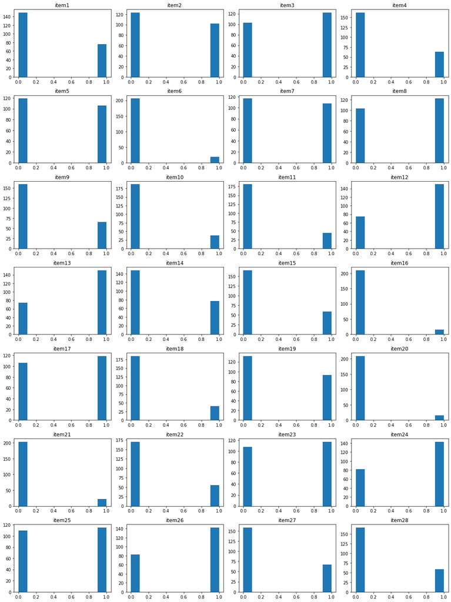

```python
import matplotlib.pyplot as plt
import seaborn as sns

fig, axes = plt.subplots(nrows=7, ncols=4, figsize=(15, 20))
for i, ax in enumerate(axes.flatten()):
    if i < len(df_imputed.columns):
        col = df_imputed.columns[i]
        ax.hist(df_imputed[col])
        ax.set_title(col)
plt.tight_layout()
plt.show()
```

# MODELISATION

```python
# 1) Créer une matrice des variables indépendantes et le vecteur de la variable dépendante.
# X est la matrice et Y est le vecteur
# La matrice des variables indépendantes est aussi appeelée matrice de featuresµ

X = df_imputed.drop('Douleur_Centrale', axis=1)  # Supprimer la colonne "target" de la matrice X
Y = df_imputed['Douleur_Centrale']              # Sélectionner uniquement la colonne "target" pour Y
```

```python
X
```

|  | item1 | item2 | item3 | item4 | item5 | item6 | item7 | item8 | item9 | item10 | ... | item19 | item20 | item21 | item22 | item23 | item24 | item25 | item26 | item27 | item28 |
| --- | --- | --- | --- | --- | --- | --- | --- | --- | --- | --- | --- | --- | --- | --- | --- | --- | --- | --- | --- | --- | --- |
| 0 | 0 | 1 | 1 | 0 | 1 | 0 | 1 | 0 | 0 | 0 | ... | 0 | 0 | 0 | 1 | 1 | 0 | 1 | 0 | 0 | 0 |
| 1 | 1 | 0 | 0 | 1 | 0 | 0 | 1 | 1 | 0 | 0 | ... | 0 | 0 | 0 | 1 | 1 | 1 | 1 | 1 | 0 | 0 |
| 2 | 0 | 0 | 0 | 0 | 1 | 0 | 1 | 0 | 0 | 0 | ... | 1 | 0 | 0 | 0 | 0 | 0 | 0 | 1 | 0 | 0 |
| 3 | 0 | 1 | 1 | 0 | 0 | 0 | 1 | 0 | 1 | 0 | ... | 1 | 0 | 0 | 0 | 1 | 1 | 0 | 0 | 0 | 0 |
| 4 | 1 | 0 | 1 | 1 | 1 | 0 | 0 | 1 | 0 | 0 | ... | 1 | 0 | 1 | 0 | 1 | 1 | 0 | 0 | 0 | 0 |
| ... | ... | ... | ... | ... | ... | ... | ... | ... | ... | ... | ... | ... | ... | ... | ... | ... | ... | ... | ... | ... | ... |
| 220 | 0 | 1 | 1 | 0 | 0 | 0 | 1 | 1 | 0 | 0 | ... | 1 | 0 | 0 | 1 | 1 | 1 | 1 | 1 | 0 | 0 |
| 221 | 1 | 1 | 1 | 0 | 1 | 0 | 1 | 0 | 0 | 0 | ... | 0 | 0 | 0 | 0 | 1 | 1 | 1 | 0 | 1 | 0 |
| 222 | 0 | 0 | 0 | 0 | 0 | 0 | 0 | 0 | 1 | 1 | ... | 1 | 0 | 0 | 0 | 1 | 1 | 0 | 0 | 0 | 0 |
| 223 | 0 | 0 | 0 | 0 | 1 | 0 | 0 | 1 | 0 | 1 | ... | 0 | 0 | 0 | 1 | 1 | 1 | 1 | 1 | 1 | 0 |
| 224 | 1 | 0 | 0 | 0 | 1 | 1 | 1 | 0 | 0 | 0 | ... | 1 | 1 | 1 | 1 | 1 | 1 | 1 | 1 | 1 | 1 |

225 rows × 28 columns

```python
Y
```

```
0      1
1      1
2      0
3      0
4      1
      ..
220    0
221    1
222    1
223    1
224    1
Name: Douleur_Centrale, Length: 225, dtype: int32
```

### Rééquilibré mon jeu de données par la méthode SMOT

La sur-échantillonnage de la classe minoritaire (oversampling): cela consiste à ajouter des copies d'observations de la classe minoritaire pour atteindre un équilibre avec la classe majoritaire. Cette technique peut être réalisée à l'aide de méthodes telles que la duplication aléatoire ou la génération synthétique de données (SMOTE)

SMOTE (Synthetic Minority Over-sampling Technique) est une méthode d'oversampling qui consiste à créer des exemples synthétiques de la classe minoritaire en interpolant de manière aléatoire les échantillons existants. Elle permet d'augmenter la taille de la classe minoritaire sans générer de copies exactes des échantillons existants, ce qui peut améliorer la généralisation du modèle

```python
!pip install imbalanced-learn
```

```python
from imblearn.over_sampling import SMOTE

# Créer un objet SMOTE
smote = SMOTE()

# Appliquer SMOTE sur les données
X_resampled, Y_resampled = smote.fit_resample(X, Y)
```

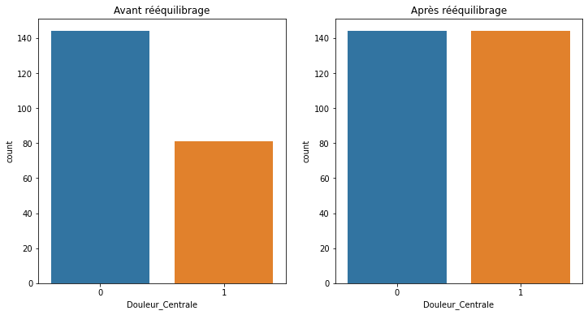

```python
# Vérifier la distribution des classes avant et après rééquilibrage
fig, axs = plt.subplots(ncols=2, figsize=(12,6))
sns.countplot(Y, ax=axs[0])
sns.countplot(Y_resampled, ax=axs[1])
axs[0].set_title("Avant rééquilibrage")
axs[1].set_title("Après rééquilibrage")
plt.show()
```

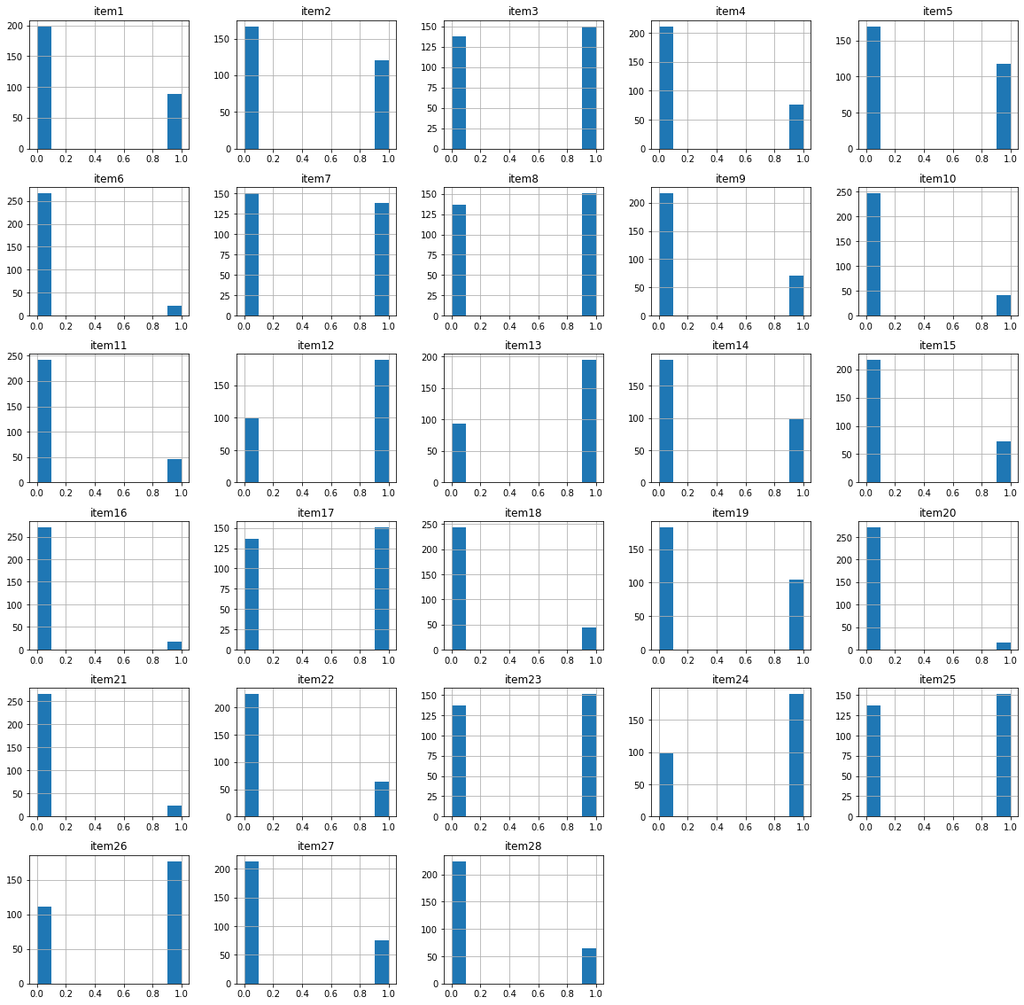

```python
# Afficher la distribution des variables de X après rééquilibrage
X_resampled.hist(figsize=(20,20))
plt.show()
```

### Séparation du dataset en training_set et en test_set

```python
from sklearn.model_selection import train_test_split

X_train, X_test, Y_train, Y_test = train_test_split(X_resampled, Y_resampled, test_size = 1/3, random_state= 0)

# Calculer la proportion de chaque ensemble
train_prop = len(X_train) / len(X)
test_prop = len(X_test) / len(X)

print("Proportion de données dans l'ensemble d'entraînement: {:.2f}".format(train_prop))
print("Proportion de données dans l'ensemble de test: {:.2f}".format(test_prop))
```

```
Proportion de données dans l'ensemble d'entraînement: 0.85
Proportion de données dans l'ensemble de test: 0.43
```

# 1- Regression Logistique

```python
from sklearn.linear_model import LogisticRegression
from sklearn.feature_selection import RFE


# Créer le modèle de régression logistique
classifierlogreg = LogisticRegression(penalty='l1', C=0.1, solver='liblinear',random_state = 0)

# Appliquer la méthode RFE pour sélectionner les variables explicatives les plus importantes
rfe = RFE(classifierlogreg, n_features_to_select=15)
rfe.fit(X_train, Y_train)

# Afficher les variables explicatives sélectionnées
print("Variables explicatives sélectionnées : ")
for i in range(len(X.columns)):
    if rfe.support_[i]:
        print(X.columns[i])

# Afficher les variables du feature selection
print("Variables du feature selection : ")
print(X.columns[rfe.support_])
```

```
Variables explicatives sélectionnées :
item5
item7
item8
item9
item10
item11
item12
item21
item22
item23
item24
item25
item26
item27
item28
Variables du feature selection :
Index(['item5', 'item7', 'item8', 'item9', 'item10', 'item11', 'item12',
       'item21', 'item22', 'item23', 'item24', 'item25', 'item26', 'item27',
       'item28'],
      dtype='object')
```

```python
Y_pred = rfe.predict(X_test)
Y_pred
```

```
array([0, 0, 1, 0, 0, 0, 0, 1, 0, 1, 1, 0, 1, 0, 0, 1, 0, 0, 0, 0, 1, 1,
       0, 1, 0, 0, 0, 1, 1, 0, 0, 0, 1, 0, 0, 1, 0, 0, 0, 1, 0, 0, 1, 0,
       1, 0, 0, 0, 0, 1, 1, 0, 1, 0, 0, 1, 0, 0, 0, 0, 0, 1, 0, 1, 0, 0,
       0, 0, 0, 1, 0, 0, 1, 1, 0, 0, 0, 0, 0, 0, 1, 0, 1, 1, 0, 1, 1, 0,
       0, 1, 0, 1, 0, 0, 0, 1])
```

### Matrice de confusion

```python
from sklearn.metrics import confusion_matrix
CM = confusion_matrix(Y_test, Y_pred)
CM
```

```
array([[36,  9],
       [27, 24]], dtype=int64)
```

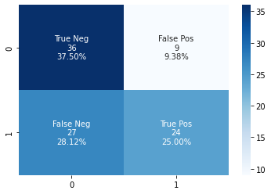

```python
group_names = ['True Neg','False Pos','False Neg','True Pos']
group_counts = ['{0:0.0f}'.format(value) for value in
                CM.flatten()]
group_percentages = ['{0:.2%}'.format(value) for value in
                     CM.flatten()/np.sum(CM)]
labels = [f'{v1}\n{v2}\n{v3}' for v1, v2, v3 in
          zip(group_names,group_counts,group_percentages)]
labels = np.asarray(labels).reshape(2,2)
sns.heatmap(CM, annot=labels, fmt='', cmap='Blues')
```

### Courbe ROC

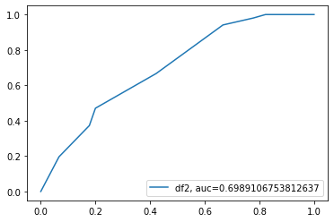

```python
from sklearn import metrics
y_pred_proba = rfe.predict_proba(X_test)[::,1]
fpr, tpr, _ = metrics.roc_curve(Y_test,  y_pred_proba)
auc = metrics.roc_auc_score(Y_test, y_pred_proba)
plt.plot(fpr,tpr,label="df2, auc="+str(auc))
plt.legend(loc=4)
plt.show()
```

La courbe ROC (Receiver Operating Characteristic) est un graphique du taux de vrais positifs par rapport au taux de faux positifs. Il montre le compromis entre sensibilité et spécificité.

### Metrics

```python
from sklearn.metrics import accuracy_score
from sklearn.metrics import f1_score
from sklearn.metrics import precision_score, recall_score
from sklearn.metrics import cohen_kappa_score
from sklearn.metrics import matthews_corrcoef
from sklearn import metrics
```

```python
Accuracy_Rate = accuracy_score(Y_test, Y_pred)
Error_rate = 1 - Accuracy_Rate
F1_score_logreg = f1_score(Y_test, Y_pred)
precision = precision_score(Y_test, Y_pred)
recall = recall_score(Y_test, Y_pred)
CK = cohen_kappa_score (Y_test,Y_pred)
MC = matthews_corrcoef(Y_test,Y_pred)
auc = metrics.roc_auc_score(Y_test, y_pred_proba)

print("precision : {:.2f}".format(precision))
print("recall : {:.2f}".format(recall))
print("Accuracy rate: ", Accuracy_Rate)
print("Error rate: ", Error_rate)
print("F1_score: ", F1_score_logreg)
print("CK:", CK)
print("MC:", MC)
print("AUC:", auc)
```

```
precision : 0.73
recall : 0.47
Accuracy rate:  0.625
Error rate:  0.375
F1_score:  0.5714285714285714
CK: 0.26436781609195403
MC: 0.28429748028367313
AUC: 0.6989106753812637
```

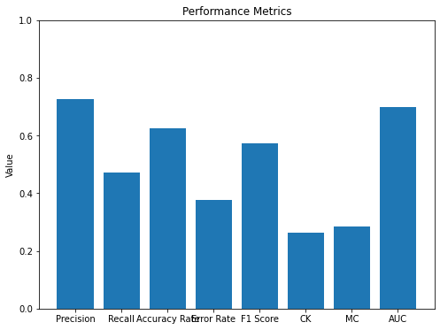

```python
# create a list of metric names and values
metric_names = ["Precision", "Recall", "Accuracy Rate", "Error Rate", "F1 Score", "CK", "MC","AUC"]
metric_values = [precision, recall, Accuracy_Rate, Error_rate, F1_score_logreg, CK, MC,auc]

# create a bar chart
fig, ax = plt.subplots(figsize=(8,6))
ax.bar(metric_names, metric_values)
ax.set_ylabel('Value')
ax.set_ylim([0,1])
ax.set_title('Performance Metrics')
plt.show()
```

# 2- Decision Tree

```python
from sklearn.tree import DecisionTreeClassifier
from boruta import BorutaPy

# Initialisation et entraînement du modèle d'arbre de décision
tree = DecisionTreeClassifier(random_state=0)
tree.fit(X_train, Y_train)
```

```
DecisionTreeClassifier(random_state=0)
```

```python
Y_pred2 = tree.predict(X_test)
Y_pred2
```

```
array([0, 1, 1, 0, 1, 1, 1, 1, 0, 0, 1, 0, 0, 0, 1, 1, 0, 0, 0, 0, 1, 1,
       0, 1, 1, 0, 0, 1, 1, 0, 0, 0, 0, 0, 0, 1, 0, 1, 0, 1, 0, 1, 1, 0,
       1, 0, 0, 0, 0, 1, 1, 0, 1, 0, 0, 1, 1, 1, 1, 0, 0, 0, 1, 1, 0, 0,
       1, 0, 1, 1, 0, 1, 1, 1, 0, 1, 0, 0, 1, 0, 1, 1, 1, 1, 0, 1, 1, 0,
       0, 1, 1, 1, 0, 0, 1, 1])
```

### Matrice de confusion

```python
CM2 = confusion_matrix(Y_test, Y_pred2)
CM2
```

```
array([[28, 17],
       [19, 32]], dtype=int64)
```

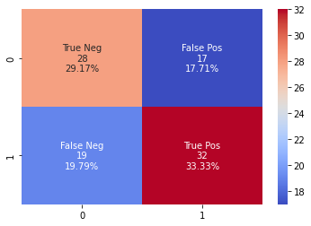

```python
group_names = ['True Neg','False Pos','False Neg','True Pos']
group_counts = ['{0:0.0f}'.format(value) for value in
                CM2.flatten()]
group_percentages = ['{0:.2%}'.format(value) for value in
                     CM2.flatten()/np.sum(CM2)]
labels = [f'{v1}\n{v2}\n{v3}' for v1, v2, v3 in
          zip(group_names,group_counts,group_percentages)]
labels = np.asarray(labels).reshape(2,2)
sns.heatmap(CM2, annot=labels, fmt='', cmap='coolwarm')
```

### Courbe roc

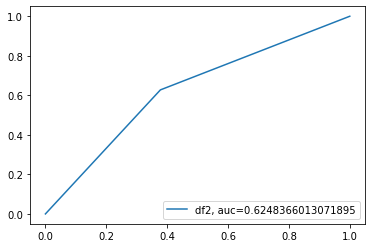

```python
y_pred_proba2 = tree.predict_proba(X_test)[::,1]
fpr, tpr, _ = metrics.roc_curve(Y_test,  y_pred_proba2)
auc = metrics.roc_auc_score(Y_test, y_pred_proba2)
plt.plot(fpr,tpr,label="df2, auc="+str(auc))
plt.legend(loc=4)
plt.show()
```

### Metrics

```python
Accuracy_Rate2 = accuracy_score(Y_test, Y_pred2)
Error_rate2 = 1 - Accuracy_Rate2  # Change variable name to Error_rate2
F1_score_logreg2 = f1_score(Y_test, Y_pred2)
precision2 = precision_score(Y_test, Y_pred2)
recall2 = recall_score(Y_test, Y_pred2)
CK2 = cohen_kappa_score(Y_test, Y_pred2)
MC2 = matthews_corrcoef(Y_test, Y_pred2)
auc2 = metrics.roc_auc_score(Y_test, y_pred_proba2)

print("precision : {:.2f}".format(precision2))
print("recall : {:.2f}".format(recall2))
print("Accuracy rate: ", Accuracy_Rate2)
print("Error rate: ", Error_rate2)
print("F1_score: ", F1_score_logreg2)
print("CK:", CK2)
print("MC:", MC2)
print("AUC:", auc2)
```

```
precision : 0.65
recall : 0.63
Accuracy rate:  0.625
Error rate:  0.375
F1_score:  0.64
CK: 0.24902216427640156
MC: 0.24923917672754117
AUC: 0.6248366013071895
```

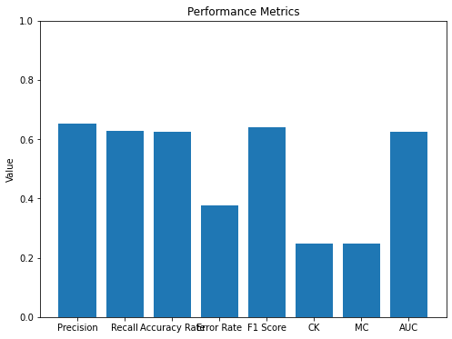

```python
# create a list of metric names and values
metric_names = ["Precision", "Recall", "Accuracy Rate", "Error Rate", "F1 Score", "CK", "MC","AUC"]
metric_values = [precision2, recall2, Accuracy_Rate2, Error_rate2, F1_score_logreg2, CK2, MC2,auc2]

# create a bar chart
fig, ax = plt.subplots(figsize=(8,6))
ax.bar(metric_names, metric_values)
ax.set_ylabel('Value')
ax.set_ylim([0,1])
ax.set_title('Performance Metrics')
plt.show()
```

# 3- RandomForest

```python
from sklearn.ensemble import RandomForestClassifier
from boruta import BorutaPy

X_train_np = X_train.to_numpy()
Y_train_np= Y_train.to_numpy()
# Création de l'estimateur RandomForestClassifier
rf = RandomForestClassifier(n_estimators=100000, n_jobs=1, max_depth=5)

# Initialisation de BorutaPy
feat_selector = BorutaPy(
    verbose=5,
    estimator=rf,
    n_estimators='auto',
    random_state=1
)

# Exécution de l'algorithme BorutaPy
feat_selector.fit(X_train_np, Y_train_np)

# Get selected features
X_train_selected = feat_selector.transform(X_train.values)
X_test_selected = feat_selector.transform(X_test.values)

# Train a machine learning model using the selected features
model = RandomForestClassifier()
model.fit(X_train_selected, Y_train)

# Get selected features
X_train_selected = feat_selector.transform(X_train.values)

# Affichage des variables sélectionnées
selected_features = pd.DataFrame({'Feature':list(X_train.columns), 'Selected':feat_selector.support_})
selected_features = selected_features[selected_features['Selected']==True]
print(selected_features)
```

[output not shown]

[output cut: 355 more lines]

```
Rejected: 	21


BorutaPy finished running.

Iteration: 	100 / 100
Confirmed: 	5
Tentative: 	1
Rejected: 	21
   Feature  Selected
4    item5      True
16  item17      True
22  item23      True
23  item24      True
24  item25      True
```

### MAX_DEPTH

Le paramètre max_depth est un hyperparamètre utilisé dans les arbres de décision et les forêts aléatoires. Il contrôle la profondeur maximale de l'arbre. Plus précisément, max_depth définit le nombre maximum de niveaux que l'arbre de décision peut avoir, c'est-à-dire le nombre maximal de divisions de l'arbre.

Une valeur plus élevée de max_depth permet à l'arbre d'être plus complexe et d'apprendre des modèles plus détaillés à partir des données d'entraînement. Cependant, cela peut également conduire à un surajustement (overfitting) si la profondeur devient trop grande.

Il est courant de régler max_depth en fonction de la taille et de la complexité des données, ainsi que de la quantité d'informations que vous souhaitez extraire de l'arbre. Une valeur par défaut est souvent utilisée, mais il est recommandé d'expérimenter avec différentes valeurs pour trouver celle qui fonctionne le mieux pour votre problème spécifique.

```python
Y_pred3 = model.predict(X_test_selected)
print(Y_test)
print(Y_pred3)
```

```
55     0
182    1
92     1
208    0
278    1
      ..
71     0
179    1
231    1
194    0
276    1
Name: Douleur_Centrale, Length: 96, dtype: int32
[0 0 1 0 1 1 0 1 1 0 0 0 0 0 0 1 0 0 0 0 1 1 0 1 0 0 0 1 1 1 0 0 1 1 0 1 0
 0 0 1 1 1 1 0 1 1 0 0 0 1 1 0 0 0 0 1 0 0 0 0 0 0 0 1 0 0 1 0 1 1 0 0 1 0
 0 1 0 1 0 0 0 1 0 1 0 1 1 0 0 0 0 1 0 1 0 0]
```

### Matrice de confusion

```python
CM3 = confusion_matrix(Y_test, Y_pred3)
CM3
```

```
array([[30, 15],
       [29, 22]], dtype=int64)
```

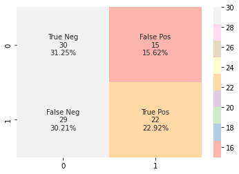

```python
group_names = ['True Neg','False Pos','False Neg','True Pos']
group_counts = ['{0:0.0f}'.format(value) for value in
                CM3.flatten()]
group_percentages = ['{0:.2%}'.format(value) for value in
                     CM3.flatten()/np.sum(CM3)]
labels = [f'{v1}\n{v2}\n{v3}' for v1, v2, v3 in
          zip(group_names,group_counts,group_percentages)]
labels = np.asarray(labels).reshape(2,2)
sns.heatmap(CM3, annot=labels, fmt='', cmap='Pastel1')
```

```python
print(Y_test.shape)
print(CM3)
```

```
(96,)
[[30 15]
 [29 22]]
```

### Courbe roc

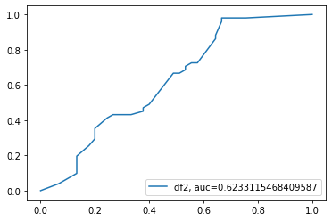

```python
Y_pred3_proba = model.predict_proba(X_test_selected)[::,1]
fpr, tpr, _ = metrics.roc_curve(Y_test,Y_pred3_proba)
auc = metrics.roc_auc_score(Y_test, Y_pred3_proba)
plt.plot(fpr,tpr,label="df2, auc="+str(auc))
plt.legend(loc=4)  #Y6_pred = model.predict(X_test_selected)
plt.show()
# La courbe roc montre la spécifité et la sensibilité
```

### Metrics

```python
Accuracy_Rate3 = accuracy_score(Y_test, Y_pred3)
Error_rate3 = 1 - Accuracy_Rate3  # Change variable name to Error_rate2
F1_score_logreg3 = f1_score(Y_test, Y_pred3)
precision3 = precision_score(Y_test, Y_pred3)
recall3 = recall_score(Y_test, Y_pred3)
CK3 = cohen_kappa_score(Y_test, Y_pred3)
MC3 = matthews_corrcoef(Y_test, Y_pred3)
auc3 = metrics.roc_auc_score(Y_test, Y_pred3)


print("precision : {:.2f}".format(precision3))
print("recall : {:.2f}".format(recall3))
print("Accuracy rate: ", Accuracy_Rate3)
print("Error rate: ", Error_rate3)
print("F1_score: ", F1_score_logreg3)
print("CK:", CK3)
print("MC:", MC3)
print("AUC:", auc3)
```

```
precision : 0.59
recall : 0.43
Accuracy rate:  0.5416666666666666
Error rate:  0.45833333333333337
F1_score:  0.5000000000000001
CK: 0.09627727856225932
MC: 0.1005227370952253
AUC: 0.5490196078431373
```

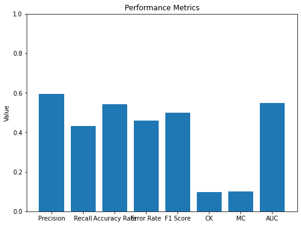

```python
# create a list of metric names and values
metric_names = ["Precision", "Recall", "Accuracy Rate", "Error Rate", "F1 Score", "CK", "MC","AUC"]
metric_values = [precision3, recall3, Accuracy_Rate3, Error_rate3, F1_score_logreg3, CK3, MC3,auc3]

# create a bar chart
fig, ax = plt.subplots(figsize=(8,6))
ax.bar(metric_names, metric_values)
ax.set_ylabel('Value')
ax.set_ylim([0,1])
ax.set_title('Performance Metrics')
plt.show()
```